# Lecture 15: Regularization

PSTAT100: Data Science — Concepts and Analysis

John Inston

johninston@ucsb.edu

University of California, Santa Barbara

October 29, 2026

## 🚁 Overview

### 📚 Required Libraries

```python
import numpy as np
import pandas as pd
import matplotlib.pyplot as plt
import seaborn as sns
from scipy import stats

import statsmodels.formula.api as smf
import statsmodels.api as sm
from statsmodels.stats.anova import anova_lm
from statsmodels.stats.outliers_influence import (
    variance_inflation_factor
)

from sklearn.datasets import fetch_california_housing
from sklearn.preprocessing import StandardScaler
from sklearn.linear_model import (
    LinearRegression,
    Ridge, Lasso, ElasticNet,
    RidgeCV, LassoCV, ElasticNetCV
)
from sklearn.model_selection import KFold, cross_val_score
from sklearn.pipeline import Pipeline
from sklearn.metrics import mean_squared_error
```

### 💅 Figure Styles

```python
sns.set_style('whitegrid')
sns.set_palette('Set2')
```

## Recap: Lecture 14 — Subset Selection

### What we established

- The **bias-variance tradeoff**: adding predictors reduces bias but inflates variance.
- **Information criteria** (AIC, BIC, adj. $R^2$) add a complexity penalty to avoid overfitting.
- **Subset selection** searches over models to find a good predictor set.

### Subset selection strategies

| Method | Start | Cost |
| --- | --- | --- |
| Best subsets | — | $2^p$ models |
| Forward stepwise | Null model | $O(p^2)$ |
| Backward stepwise | Full model | $O(p^2)$ |
| Hybrid | Either | $O(p^2)$ |

## Example: Housing Data

### We have been looking at California housing data!

```python
# Load dataset — used throughout this lecture
housing = fetch_california_housing(as_frame=True)
df = housing.frame.copy()
df.columns = [c.lower() for c in df.columns]

predictors = ['medinc','houseage','averooms','avebedrms',
              'aveoccup','population','latitude','longitude']
feature_names = ['MedInc','HouseAge','AveRooms','AveBedrms',
                 'AveOccup','Population','Latitude','Longitude']

X_full = df[predictors].values
y_full = df['medhouseval'].values
# Standardize predictors for regularization
X_scaled = StandardScaler().fit_transform(X_full)
```

## Limitations of Subset Selection

Subset selection methods are powerful but carry important limitations that become severe as $p$ grows.

| Limitation | Detail |
| --- | --- |
| **Computational cost** | Best subsets requires $2^p$ fits — infeasible for $p \gtrsim 30$ |
| **Greedy, not global** | Stepwise methods can miss the truly optimal subset |
| **Discrete selection** | Each predictor is either in or out — no gradation of importance |
| **Instability** | Small changes in the data can produce very different selected subsets |
| **Fails when $p \geq n$** | The full model cannot be estimated when predictors outnumber observations |

> **Regularization** (this lecture) overcomes all of these: it is computationally cheap, globally optimised, produces continuous coefficient values, is stable, and works when $p \gg n$.

# Cross-Validation

## 🔄 Why Cross-Validation?

### The problem with in-sample fit

- RSS, $R^2$, and the likelihood are computed on the **training data** — the same data used to fit the model.
- The model has already “seen” these observations: in-sample fit is optimistic.

### The solution: hold out data

- **Cross-validation** repeatedly splits the data into a training set and a validation set.
- Model error is evaluated on observations the model **has not seen during fitting**.
- This gives an honest estimate of **out-of-sample (generalisation) error**.

> Cross-validation is also our main tool for **choosing the regularization hyperparameter** $\lambda$ — we will return to it in the regularization section.

## $k$-Fold Cross-Validation

**$k$-fold CV**

1. Randomly partition the $n$ observations into $k$ roughly equal **folds**.
2. For each fold $j = 1, \ldots, k$: fit the model on the other $k-1$ folds, predict on fold $j$.
3. Report the average test error:
   $$\text{CV}_{(k)} = \frac{1}{n} \sum_{i=1}^n (y_i - \hat{y}_i^{(-\kappa(i))})^2,$$
   where $\hat{y}_i^{(-\kappa(i))}$ is the prediction for observation $i$ from the model fit without its fold $\kappa(i)$.
- **$k = 5$ or $k = 10$** are standard choices — they balance bias and variance of the CV estimate well.
- **$k = n$ (LOOCV)**: leave one observation out at a time — low bias, but high variance and expensive.

## LOOCV and the Hat Matrix

For OLS, there is a remarkable **shortcut** that avoids refitting the model $n$ times:

$$\text{LOOCV} = \frac{1}{n}\sum_{i=1}^n \left(\frac{e_i}{1 - h_{ii}}\right)^2,$$

where $e_i = y_i - \hat{y}_i$ is the ordinary residual and $h_{ii}$ is the $i$-th diagonal of the hat matrix $\mathbf{H}$.

### Why does this work?

- When observation $i$ is removed, the prediction at $x_i$ changes by $e_i / (1 - h_{ii})$.
- Observations with **high leverage** $h_{ii}$ have a large influence on the LOOCV score — they are “risky” in the sense that leaving them out changes the fit substantially.
- This formula is computationally free once $\mathbf{H}$ is computed.

## $k$-Fold CV in Python with `sklearn`

```python
kf = KFold(n_splits=10, shuffle=True, random_state=0)

# Compare subsets of features using 10-fold CV MSE
feature_sets = {
    '1 predictor (MedInc)': X_full[:, [0]],
    '3 predictors': X_full[:, :3],
    '5 predictors': X_full[:, :5],
    'Full (8 predictors)': X_full,
}

print(f"{'Model':<30} {'10-fold CV MSE':>16}")
print("-" * 48)
for name, X_sub in feature_sets.items():
    scores = cross_val_score(
        LinearRegression(), X_sub, y_full,
        cv=kf, scoring='neg_mean_squared_error'
    )
    print(f"{name:<30} {-scores.mean():>16.4f}")
```

```
Model                            10-fold CV MSE
------------------------------------------------
1 predictor (MedInc)                     0.7013
3 predictors                             0.6514
5 predictors                             0.6189
Full (8 predictors)                      0.5279
```

## LOOCV via the Hat Matrix

```python
# LOOCV shortcut using the hat matrix
X_aug = sm.add_constant(
    df[['medinc','houseage','averooms','avebedrms',
        'aveoccup','population','latitude','longitude']]
)
fit_full = sm.OLS(y_full, X_aug).fit()
H        = X_aug @ np.linalg.solve(X_aug.T @ X_aug, X_aug.T)
h_diag   = np.diag(H)
e        = fit_full.resid

loocv = np.mean((e / (1 - h_diag))**2)
print(f"LOOCV MSE (hat-matrix shortcut): {loocv:.4f}")
```

```
LOOCV MSE (hat-matrix shortcut): 0.5282
```

# Regularization (Shrinkage Methods)

## 🎯 Why Regularize?

### The problem with OLS in high dimensions

- When $p$ is large relative to $n$, or when predictors are highly correlated, $(\mathbf{X}^\top\mathbf{X})^{-1}$ becomes ill-conditioned.
- OLS coefficients have **high variance** — tiny changes in the data lead to large changes in $\hat{\boldsymbol{\beta}}$.

### The regularization idea

- Add a **penalty** on the size of $\boldsymbol{\beta}$ to the least squares objective.
- Trading a little bias for a large reduction in variance can lower total test error.

> This is exactly the bias-variance tradeoff in action: we deliberately introduce bias to tame variance.

## Regularization as Constrained Optimization

Regularization can be written in two equivalent forms.

**Penalty (Lagrangian) form** — what we minimize:

$$\min_{\boldsymbol{\beta}}\; \|\mathbf{y} - \mathbf{X}\boldsymbol{\beta}\|^2_2 + \lambda\|\boldsymbol{\beta}\|_q$$

**Constraint form** — equivalent formulation:

$$\min_{\boldsymbol{\beta}}\; \|\mathbf{y} - \mathbf{X}\boldsymbol{\beta}\|^2_2 \quad \text{subject to} \quad \|\boldsymbol{\beta}\|_q \leq t$$

- For every value of $\lambda \geq 0$ there is a corresponding budget $t \geq 0$ that produces the same solution.
- **As $\lambda$ increases, $t$ decreases** — the constraint tightens and coefficients must shrink further.
- At $\lambda = 0$ ($t = \infty$): no constraint — recovers the OLS solution.
- At $\lambda \to \infty$ ($t = 0$): all $\hat{\beta}_j = 0$ — the null model.

> The constraint perspective makes the geometry transparent: the regularized solution is the point on the constraint region $\|\boldsymbol{\beta}\|_q \leq t$ that is closest to the OLS solution.

## ⚠️ Why Standardize Predictors?

The regularization penalty $\lambda \sum_j \beta_j^2$ (or $\lambda \sum_j |\beta_j|$) penalizes **coefficients by their magnitude**.

### The scale problem

- Suppose $X_1$ is measured in **millions of dollars** and $X_2$ in **metres**.
- A unit change in $X_1$ moves the response by $\beta_1$ — but $\beta_1$ will naturally be tiny (because the units are huge).
- A unit change in $X_2$ moves the response by $\beta_2$ — with larger units, $\beta_2$ can be larger.
- The penalty then falls almost entirely on $\beta_2$, **unfairly shrinking it relative to $\beta_1$**.

### The fix: standardize before fitting

$$X_j \leftarrow \frac{X_j - \bar{X}_j}{s_j}$$

This puts all predictors on a **unit-variance, zero-mean** scale so the penalty is applied equally.

> **Important**: the intercept $\beta_0$ is **never penalized** — shrinking it would shift all predictions by the mean of $y$, which is not what we want.

## Ridge Regression ($L_2$ Penalty)

**Ridge Regression**

$$\hat{\boldsymbol{\beta}}_{\text{ridge}} = \underset{\boldsymbol{\beta}}{\arg\min}\; \|\mathbf{y} - \mathbf{X}\boldsymbol{\beta}\|^2_2 + \lambda\|\boldsymbol{\beta}\|^2_2,$$

where $\lambda \geq 0$ is the **regularization hyperparameter** and $\|\boldsymbol{\beta}\|^2_2 = \sum_j \beta_j^2$ is the squared $L_2$ norm.

**Closed-form solution**:

$$\hat{\boldsymbol{\beta}}_{\text{ridge}} = (\mathbf{X}^\top\mathbf{X} + \lambda \mathbf{I})^{-1}\mathbf{X}^\top\mathbf{y}.$$

**Why does adding $\lambda\mathbf{I}$ help?** Think in terms of eigenvalues.

## Regularization and Eigenvalues

### Impact of $\lambda$.

- $\mathbf{X}^\top\mathbf{X}$ is a symmetric positive semi-definite matrix with eigenvalues $\lambda_1 \geq \lambda_2 \geq \cdots \geq \lambda_p \geq 0$.
- The OLS inverse involves $1/\lambda_j$ for each eigenvalue. If any $\lambda_j \approx 0$ (nearly singular — which happens when predictors are correlated), that term explodes, inflating $\text{Var}(\hat{\boldsymbol{\beta}})$.
- Adding $\lambda\mathbf{I}$ **shifts every eigenvalue up by $\lambda$**: the eigenvalues of $\mathbf{X}^\top\mathbf{X} + \lambda\mathbf{I}$ are $\lambda_j + \lambda$.
- The inverse now involves $1/(\lambda_j + \lambda)$ — even if $\lambda_j \approx 0$, the denominator is at least $\lambda > 0$, so it stays bounded.

The matrix is therefore always invertible for any $\lambda > 0$, regardless of multicollinearity.

- Ridge shrinks all coefficients **toward zero** but **never sets them exactly to zero** — all predictors are retained.
- Particularly useful when predictors are correlated (multicollinearity).
- Predictors must be **standardised** first (the penalty is scale-sensitive).

## Ridge: The Effect of $\lambda$

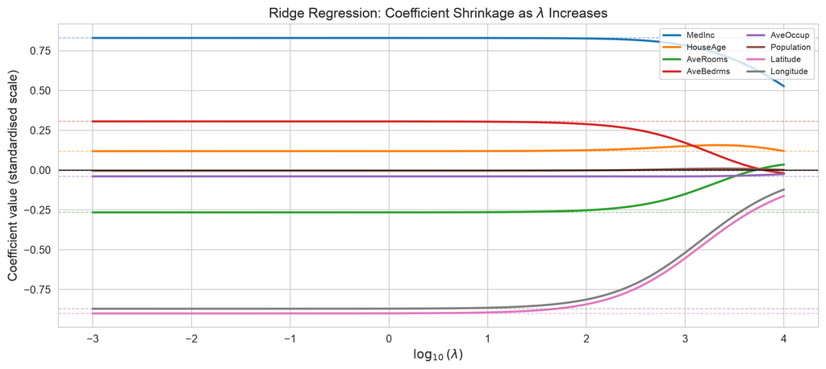

As λ increases (moving right), Ridge coefficients are smoothly shrunk toward zero. All predictors remain in the model — none are zeroed out. Dashed horizontal lines show the OLS coefficient values (λ = 0 limit). Note: coefficients are on the standardised scale.

## Lasso ($L_1$ Penalty)

**Lasso — Least Absolute Shrinkage and Selection Operator**

$$\hat{\boldsymbol{\beta}}_{\text{lasso}} = \underset{\boldsymbol{\beta}}{\arg\min}\; \|\mathbf{y} - \mathbf{X}\boldsymbol{\beta}\|^2_2 + \lambda\|\boldsymbol{\beta}\|_1,$$

where $\|\boldsymbol{\beta}\|_1 = \sum_j |\beta_j|$ is the $L_1$ norm.

- **No closed-form solution** — requires coordinate descent or convex optimization.
- The $L_1$ penalty induces **sparsity**: for large enough $\lambda$, some $\hat{\beta}_j$ are set **exactly to zero**.
- Lasso performs **automatic variable selection** — it simultaneously shrinks and selects.
- Like Ridge, predictors must be standardised.

> The key difference: Ridge shrinks coefficients toward zero uniformly; Lasso can zero them out completely.

## Lasso: Why Does Sparsity Happen?

Recall the constraint form: minimize RSS subject to $\|\boldsymbol{\beta}\|_1 \leq t$.

- The **$L_1$ constraint region** (diamond) has **corners on the coordinate axes**.
- The RSS contours are ellipses centred at the OLS solution, expanding outward.
- As we shrink $t$, the ellipse first touches the diamond.
- Because the diamond has **sharp corners**, contact most often occurs at a corner — where one or more $\beta_j = 0$ **exactly**.

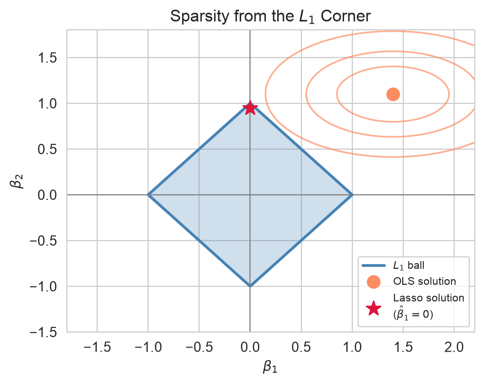

The L₁ ball (diamond) has corners where an axis meets the boundary. The expanding RSS ellipse tends to first touch a corner, setting one coefficient exactly to zero.

> This geometry is why $L_2$ (Ridge) never produces exactly-zero coefficients: the smooth $L_2$ ball has no corners, so the ellipse touches it at a non-axis point.

## Ridge vs. Lasso: Geometry

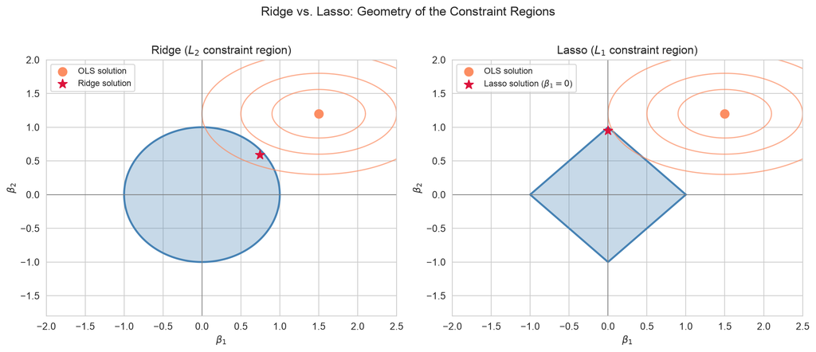

Constraint regions for Ridge (circle, L₂ ball) and Lasso (diamond, L₁ ball). The OLS solution is at the unconstrained minimum. The Lasso constraint region has corners along the axes, making it likely that the constrained minimum falls on a corner — setting one coefficient exactly to zero.

## Elastic Net

**Elastic Net**

$$\hat{\boldsymbol{\beta}}_{\text{EN}} = \underset{\boldsymbol{\beta}}{\arg\min}\; \|\mathbf{y} - \mathbf{X}\boldsymbol{\beta}\|^2_2 + \lambda\!\left[\alpha\|\boldsymbol{\beta}\|_1 + \frac{1-\alpha}{2}\|\boldsymbol{\beta}\|^2_2\right],$$

where $\alpha \in [0, 1]$ controls the mix: $\alpha = 1$ is pure Lasso, $\alpha = 0$ is pure Ridge.

- **Combines** the sparsity of Lasso with the grouping property of Ridge.
- When predictors are **correlated**, Lasso tends to arbitrarily select one from a group; Elastic Net tends to **select the group together**.
- Two hyperparameters: $\lambda$ (overall penalty strength) and $\alpha$ (L1 vs. L2 mix).

## Ridge vs. Lasso — Practical Guidance

|  | Ridge | Lasso | Elastic Net |
| --- | --- | --- | --- |
| **Variable selection** | No | Yes | Yes |
| **Correlated predictors** | Handles well | Picks one arbitrarily | Selects group |
| **Works when $p > n$** | Yes | Yes (selects $\leq n$) | Yes |
| **Interpretability** | All retained | Sparse | Sparse |
| **Inference on $\hat{\beta}$** | Non-standard | Non-standard | Non-standard |

### Rules of thumb

- Use **Ridge** when you expect a **dense signal** — most predictors contribute something.
- Use **Lasso** when you expect **sparsity** — only a few predictors truly matter.
- Use **Elastic Net** when predictors are **correlated and sparse** — combines the best of both.
- When $p \gg n$, prefer Lasso or Elastic Net to obtain an interpretable sparse model.

## Choosing $\lambda$: Cross-Validated Grid Search

```python
# RidgeCV — built-in leave-one-out CV over a grid of alpha values
ridge_cv  = RidgeCV(alphas=np.logspace(-3, 4, 100), cv=10)
ridge_cv.fit(X_scaled, y_full)
print(f"Ridge best λ (alpha): {ridge_cv.alpha_:.4f}")

# LassoCV — coordinate descent + k-fold CV
lasso_cv = LassoCV(alphas=np.logspace(-4, 1, 100),
                   cv=10, max_iter=10_000, random_state=0)
lasso_cv.fit(X_scaled, y_full)
print(f"Lasso best λ (alpha): {lasso_cv.alpha_:.6f}")
```

```
Ridge best λ (alpha): 89.0215
Lasso best λ (alpha): 0.000320
```

## Coefficient Path Plots

```python
alphas = np.logspace(-3, 4, 200)

# Ridge path
ridge_coefs = np.array([
    Ridge(alpha=a).fit(X_scaled, y_full).coef_
    for a in alphas
])

# Lasso path
lasso_coefs = np.array([
    Lasso(alpha=a, max_iter=10000).fit(X_scaled, y_full).coef_
    for a in alphas
])

fig, axes = plt.subplots(1, 2, figsize=(14, 5))

palette = sns.color_palette('tab10', n_colors=8)

for j, name in enumerate(feature_names):
    axes[0].plot(np.log10(alphas), ridge_coefs[:, j],
                 lw=1.8, color=palette[j], label=name)
    axes[1].plot(np.log10(alphas), lasso_coefs[:, j],
                 lw=1.8, color=palette[j], label=name)

for ax, title, best_a in [
    (axes[0], 'Ridge Coefficient Path', ridge_cv.alpha_),
    (axes[1], 'Lasso Coefficient Path', lasso_cv.alpha_),
]:
    ax.axvline(np.log10(best_a), color='crimson', lw=2,
               linestyle='--', label=f'CV-selected $\\lambda$')
    ax.axhline(0, color='gray', lw=0.8)
    ax.set_xlabel('$\\log_{10}(\\lambda)$')
    ax.set_ylabel('Coefficient value')
    ax.set_title(title)
    ax.legend(fontsize=7, ncol=2)

plt.suptitle('Regularization Paths — California Housing', fontsize=13, y=1.02)
plt.tight_layout(); plt.show()
```

## Coefficient Path Plots

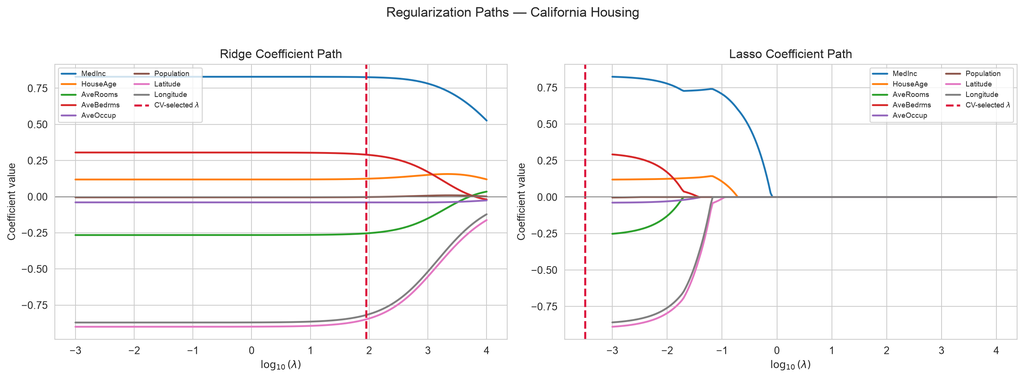

# Implementation in Python

## 🗺️ The Dataset: Diabetes

We use `sklearn`’s built-in **diabetes dataset** (GeeksForGeeks 2024), a classic regression benchmark.

- $n = 442$ patients; response = **disease progression** one year after baseline (continuous).
- $p = 10$ predictors: age, sex, BMI, blood pressure, and six blood serum measurements.
- Predictors are **already mean-centred and scaled** by `sklearn`.

```python
from sklearn.datasets import load_diabetes

diabetes = load_diabetes()
X_diab = pd.DataFrame(diabetes.data, columns=diabetes.feature_names)
y_diab = pd.Series(diabetes.target, name='progression')

print(X_diab.shape)
print(y_diab.describe().round(1))
```

```
(442, 10)
count    442.0
mean     152.1
std       77.1
min       25.0
25%       87.0
50%      140.5
75%      211.5
max      346.0
Name: progression, dtype: float64
```

## Step 1: Train-Test Split

Before fitting any model we hold out 25% of the data as a **test set** — this will never be seen during training or hyperparameter tuning.

```python
from sklearn.model_selection import train_test_split

X_train, X_test, y_train, y_test = train_test_split(
    X_diab, y_diab, test_size=0.25, random_state=42
)

print(f"Training set: {X_train.shape[0]} observations")
print(f"Test set:     {X_test.shape[0]} observations")
```

```
Training set: 331 observations
Test set:     111 observations
```

> Because the predictors are already scaled in this dataset, we do not need to apply `StandardScaler` here. In general, you should always scale when using regularized methods.

## Step 2: Fitting Ridge Regression

We fit Ridge with `alpha=1` ($\lambda = 1$) as a starting point, then inspect the coefficients.

```python
# Fit Ridge with α = 1
ridge_model = Ridge(alpha=1)
ridge_model.fit(X_train, y_train)
y_pred_ridge = ridge_model.predict(X_test)

# Test MSE
mse_ridge = np.mean((y_pred_ridge - y_test)**2)
print(f"Ridge (α=1) — Test MSE: {mse_ridge:.2f}\n")

# Coefficient table
ridge_coef_df = pd.DataFrame({
    'Feature':    X_train.columns,
    'Coefficient': ridge_model.coef_
}).sort_values('Coefficient', key=abs, ascending=False)

print(ridge_coef_df.round(2).to_string(index=False))
```

## Step 2: Fitting Ridge Regression

```
Ridge (α=1) — Test MSE: 3105.47

Feature  Coefficient
    bmi       278.30
     s5       215.85
     bp       197.62
     s3      -151.39
     s4       120.32
     s6       101.76
    sex       -67.72
    age        50.55
     s2       -26.23
     s1        -6.25
```

## Step 3: Fitting Lasso Regression

We fit Lasso with `alpha=1`. Notice that some coefficients are set **exactly to zero** — Lasso has performed automatic variable selection.

```python
# Fit Lasso with α = 1
lasso_model = Lasso(alpha=1)
lasso_model.fit(X_train, y_train)
y_pred_lasso = lasso_model.predict(X_test)

# Test MSE
mse_lasso = np.mean((y_pred_lasso - y_test)**2)
print(f"Lasso (α=1) — Test MSE: {mse_lasso:.2f}\n")

# Coefficient table — mark zeroed-out predictors
lasso_coef_df = pd.DataFrame({
    'Feature':    X_train.columns,
    'Coefficient': lasso_model.coef_,
    'Selected':    lasso_model.coef_ != 0
}).sort_values('Coefficient', key=abs, ascending=False)

print(f"Features retained: {(lasso_model.coef_ != 0).sum()} / {X_train.shape[1]}\n")
print(lasso_coef_df.round(2).to_string(index=False))
```

## Step 3: Fitting Lasso Regression

```
Lasso (α=1) — Test MSE: 3433.16

Features retained: 3 / 10

Feature  Coefficient  Selected
    bmi       398.39      True
     s5       238.19      True
     bp        46.18      True
    age         0.00     False
    sex        -0.00     False
     s1         0.00     False
     s2         0.00     False
     s3        -0.00     False
     s4         0.00     False
     s6         0.00     False
```

## Step 4: Fitting Elastic Net

Elastic Net adds a second hyperparameter `l1_ratio` ($\alpha$ in our notation) controlling the L1/L2 mix. Here we use `l1_ratio=0.5` — equal weight to both penalties.

```python
# Fit Elastic Net with λ=1, α=0.5
enet_model = ElasticNet(alpha=1, l1_ratio=0.5)
enet_model.fit(X_train, y_train)
y_pred_enet = enet_model.predict(X_test)

# Test MSE
mse_enet = np.mean((y_pred_enet - y_test)**2)
print(f"Elastic Net (α=1, l1_ratio=0.5) — Test MSE: {mse_enet:.2f}\n")

# Coefficient table
enet_coef_df = pd.DataFrame({
    'Feature':    X_train.columns,
    'Coefficient': enet_model.coef_,
    'Selected':    enet_model.coef_ != 0
}).sort_values('Coefficient', key=abs, ascending=False)

print(f"Features retained: {(enet_model.coef_ != 0).sum()} / {X_train.shape[1]}\n")
print(enet_coef_df.round(2).to_string(index=False))
```

## Step 4: Fitting Elastic Net

```
Elastic Net (α=1, l1_ratio=0.5) — Test MSE: 5554.23

Features retained: 9 / 10

Feature  Coefficient  Selected
    bmi         3.30      True
     s5         2.95      True
     bp         2.26      True
     s4         2.14      True
     s3        -1.87      True
     s6         1.70      True
    age         0.41      True
     s1         0.34      True
     s2         0.08      True
    sex         0.00     False
```

## Step 5: Choosing $\lambda$ by Cross-Validation

`alpha=1` was arbitrary. We use built-in CV classes to search over a grid and find the optimal $\lambda$ for each method.

```python
# Ridge: CV over grid
ridge_cv_diab = RidgeCV(alphas=np.logspace(-3, 4, 100), cv=10)
ridge_cv_diab.fit(X_train, y_train)

# Lasso: CV over grid
lasso_cv_diab = LassoCV(alphas=np.logspace(-3, 2, 100),
                        cv=10, max_iter=10_000, random_state=42)
lasso_cv_diab.fit(X_train, y_train)

# Elastic Net: CV over grid
enet_cv_diab = ElasticNetCV(alphas=np.logspace(-3, 2, 100),
                            l1_ratio=[0.1, 0.5, 0.7, 0.9, 1.0],
                            cv=10, max_iter=10_000, random_state=42)
enet_cv_diab.fit(X_train, y_train)

print(f"Ridge   best λ: {ridge_cv_diab.alpha_:.4f}")
print(f"Lasso   best λ: {lasso_cv_diab.alpha_:.4f}")
print(f"ElasNet best λ: {enet_cv_diab.alpha_:.4f},  "
      f"best l1_ratio: {enet_cv_diab.l1_ratio_:.2f}")
```

## Step 5: Choosing $\lambda$ by Cross-Validation

```
Ridge   best λ: 0.0955
Lasso   best λ: 0.0045
ElasNet best λ: 0.0045,  best l1_ratio: 1.00
```

## Step 6: Comparing All Methods

```python
# OLS baseline
ols_model = LinearRegression().fit(X_train, y_train)

models = {
    'OLS':                    ols_model,
    'Ridge (α=1)':            ridge_model,
    'Ridge (CV-tuned)':       ridge_cv_diab,
    'Lasso (α=1)':            lasso_model,
    'Lasso (CV-tuned)':       lasso_cv_diab,
    'Elastic Net (CV-tuned)': enet_cv_diab,
}

print(f"{'Method':<28} {'Test MSE':>10} {'# Features':>12}")
print("-" * 52)
for name, mdl in models.items():
    y_hat = mdl.predict(X_test)
    mse   = np.mean((y_hat - y_test)**2)
    # count non-zero coefficients (OLS and Ridge always keep all)
    coefs = mdl.coef_
    n_feat = (coefs != 0).sum() if hasattr(mdl, 'coef_') else 10
    print(f"{name:<28} {mse:>10.2f} {n_feat:>12}")
```

## Step 6: Comparing All Methods

```
Method                         Test MSE   # Features
----------------------------------------------------
OLS                             2848.31           10
Ridge (α=1)                     3105.47           10
Ridge (CV-tuned)                2810.61           10
Lasso (α=1)                     3433.16            3
Lasso (CV-tuned)                2839.42            9
Elastic Net (CV-tuned)          2839.42            9
```

## Visualising the Results

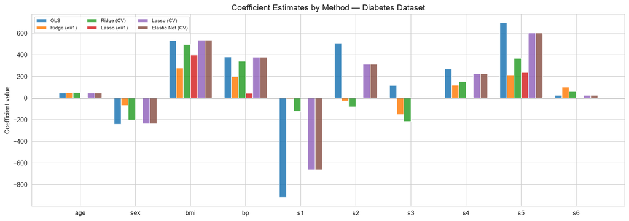

Coefficient estimates for all six methods on the diabetes dataset. OLS and Ridge retain all 10 features; Lasso and Elastic Net zero out some. CV tuning substantially changes the estimates compared to α=1.

# Conclusion

## ✅ What We Covered

- **Limitations of subset selection**: discrete, greedy, and unstable for large $p$.
- **Cross-validation**: honest out-of-sample error estimation; the key tool for choosing $\lambda$.
- **Regularization**: Ridge ($L_2$) shrinks smoothly; Lasso ($L_1$) shrinks and selects; Elastic Net combines both.
- **Constrained optimization view**: regularization = fitting RSS subject to a norm ball constraint.
- **Standardization**: essential before applying any penalized method.
- **Implementation**: fitting Ridge, Lasso, and Elastic Net in `sklearn`, with CV-tuned $\lambda$.

## 📅 What’s Next?

- **Classification models**: logistic regression, support vector machines, decision trees.
- **Non-linear regression** and basis expansions.

## References

GeeksForGeeks. 2024. *Implementation of Lasso, Ridge and Elastic Net*. [Https://www.geeksforgeeks.org/machine-learning/implementation-of-lasso-ridge-and-elastic-net/](https://www.geeksforgeeks.org/machine-learning/implementation-of-lasso-ridge-and-elastic-net/).